# CS 464

```
Macro Precision: 0.46666133162612033 Macro Recall: 0.5519688644688645 Macro F1: 0.5000558001461963
Accuracy 0.6133333333333333
Accuracies for each class:
	Accuracy for Cloudy           0.5192307692307693
	Accuracy for Rain             0.0
	Accuracy for Shine            0.7142857142857143
	Accuracy for Sunrise          0.9743589743589743
```

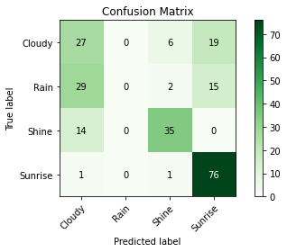

```python
# The performance metrics are calculated according to the parameteres below  (PARAMETER EXTRA TRIAL 3) batchsize = 44, lr=0.1

"""
Plot for the listed parameters below:
max_epoch = 14
train_batch = 44
test_batch = 44
learning_rate = 0.1
momentum = 0.5
weight_decay = 5e-04
"""


model_fcn = FCNet()
model_fcn.load_state_dict(torch.load(PATH_FCN_SGD))

# evaluate on test set
# model = model.eval()

predictions = []

with torch.no_grad():
#   iterate over test batches
    for data in test_loader:
        images, labels = data
        images = images.permute(0, 3, 1, 2)
        #images, labels = images.cuda(), labels.cuda()
        outputs = model_fcn(images.float())
        _, predicted2 = torch.max(outputs.data, 1)
        predictions.extend(predicted2.tolist())

#   get confusion matrix
#   calculate accuracy
#   calculate precision
#   calculate recall
#   calculate F1 score
labelAndNames = {0: "Cloudy", 1: "Rain", 2: "Shine", 3: "Sunrise"}
cm = confusion_matrix(y_test,predictions)
# plot confusion matrix
plot_cm(cm, labelAndNames.values())
pscore = precision_score(y_test, predictions, average="macro")
rscore = recall_score(y_test, predictions, average="macro")
f1 = f1_score(y_test, predictions, average="macro")
print("Macro Precision:", pscore, "Macro Recall:", rscore,"Macro F1:" ,f1)
print("Accuracy", accuracy_score(y_test,predictions))
acc_per_class = cm.diagonal()/cm.sum(1)
print("Accuracies for each class:")
for i, acc in enumerate(acc_per_class):
    print(f'\tAccuracy for {labelAndNames[i]}'.ljust(30, ' '), acc)
```

```python
# The model trained according to the parameteres below (PARAMETER EXTRA TRIAL 4) BATCHSIZE= 44, LR=5e-2

max_epoch = 14
train_batch = 44
test_batch = 44
learning_rate = 5e-2
momentum = 0.5
weight_decay = 5e-04

model_FCN = FCNet()
criterion = nn.CrossEntropyLoss()
min_vald_loss = np.inf
optimizer = torch.optim.SGD(model_FCN.parameters(), lr=learning_rate, weight_decay=5e-04)

PATH_FCN_SGD = "/content/drive/MyDrive/CS464_HW3/best_fcn_sgd.pth"
min_vald_loss = np.inf
history = {'train_accuracy': [], 'vald_accuracy':[], 'train_loss': [], 'vald_loss': []}

for epoch in range(max_epoch):
    train_loss = 0.0
    train_correct = 0
    for i, data in enumerate(train_loader, 0):
        inputs, labels = data
        optimizer.zero_grad()
        input = inputs.permute(0, 3, 1, 2)
        outputs = model_FCN(input.float())
        preds = torch.argmax(outputs, dim=1)
        train_correct += torch.sum(preds==labels)
        loss = criterion(outputs, labels)
        loss.backward()
        optimizer.step()
        train_loss += loss.item()

    with torch.no_grad():
        vald_loss = 0.0
        vald_correct = 0
        for data in validation_loader:
            images, labels = data
            images = images.permute(0, 3, 1, 2)
            outputs = model_FCN(images.float())
            preds = torch.argmax(outputs, dim=1)
            vald_correct += torch.sum(preds==labels)
            loss = criterion(outputs, labels)
            vald_loss += loss.item()

    print(f'Epoch {epoch+1}:\t\t train_loss: {(train_loss / len(train_loader)):.2f}\t\t train_accuracy: {(train_correct / (len(train_loader) * train_batch)):.2f}\t\t validation_loss: {(vald_loss / len(validation_loader)):.2f}\t\t validation_accuracy: {(vald_correct / (len(validation_loader) * test_batch)):.2f}')
    if (vald_loss / len(validation_loader)) < min_vald_loss:
        print(f'Saving new best FCN SGD with vald_loss: {(vald_loss / len(validation_loader)):.2f}')
        min_vald_loss = (vald_loss / len(validation_loader))
        torch.save(model_FCN.state_dict(), PATH_FCN_SGD)

    history['train_loss'].append(train_loss / len(train_loader))
    history['vald_loss'].append(vald_loss / len(validation_loader))
    history['train_accuracy'].append(train_correct / (len(train_loader) * train_batch))
    history['vald_accuracy'].append(vald_correct / (len(validation_loader) * test_batch))

print(f'Best validation loss: {min_vald_loss}')
```

```
Epoch 1:		 train_loss: 1.29		 train_accuracy: 0.46		 validation_loss: 1.03		 validation_accuracy: 0.76
Saving new best FCN SGD with vald_loss: 1.03
Epoch 2:		 train_loss: 1.38		 train_accuracy: 0.57		 validation_loss: 1.18		 validation_accuracy: 0.52
Epoch 3:		 train_loss: 1.22		 train_accuracy: 0.57		 validation_loss: 1.06		 validation_accuracy: 0.57
Epoch 4:		 train_loss: 0.98		 train_accuracy: 0.72		 validation_loss: 1.20		 validation_accuracy: 0.55
Epoch 5:		 train_loss: 0.93		 train_accuracy: 0.80		 validation_loss: 1.19		 validation_accuracy: 0.68
Epoch 6:		 train_loss: 0.97		 train_accuracy: 0.80		 validation_loss: 1.13		 validation_accuracy: 0.66
Epoch 7:		 train_loss: 0.87		 train_accuracy: 0.85		 validation_loss: 1.09		 validation_accuracy: 0.68
Epoch 8:		 train_loss: 0.82		 train_accuracy: 0.86		 validation_loss: 1.02		 validation_accuracy: 0.76
Saving new best FCN SGD with vald_loss: 1.02
Epoch 9:		 train_loss: 0.76		 train_accuracy: 0.94		 validation_loss: 0.88		 validation_accuracy: 0.77
Saving new best FCN SGD with vald_loss: 0.88
Epoch 10:		 train_loss: 0.73		 train_accuracy: 0.95		 validation_loss: 0.68		 validation_accuracy: 0.95
Saving new best FCN SGD with vald_loss: 0.68
Epoch 11:		 train_loss: 0.80		 train_accuracy: 0.93		 validation_loss: 0.71		 validation_accuracy: 0.92
Epoch 12:		 train_loss: 0.79		 train_accuracy: 0.98		 validation_loss: 0.75		 validation_accuracy: 0.91
Epoch 13:		 train_loss: 0.66		 train_accuracy: 1.03		 validation_loss: 1.12		 validation_accuracy: 0.77
Epoch 14:		 train_loss: 0.88		 train_accuracy: 0.87		 validation_loss: 0.83		 validation_accuracy: 0.90
Best validation loss: 0.6806013882160187
```

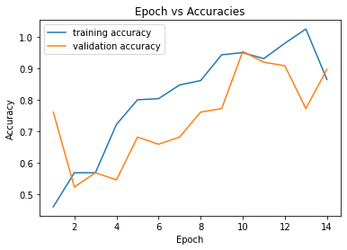

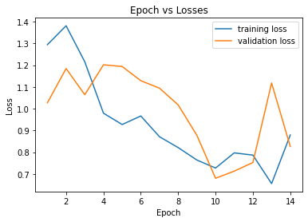

```python
# The graphs plotted according to the parameteres below  (PARAMETER EXTRA  TRIAL 4) batchsize = 44, lr=5e-2
"""
Plot for the listed parameters below:
max_epoch = 14
train_batch = 44
test_batch = 44
learning_rate = 5e-2
momentum = 0.5
weight_decay = 5e-04
"""

# plot accuracies vs epoch -- PLOT 1
plt.plot([i+1 for i in range(max_epoch)], history['train_accuracy'], label='training accuracy')
plt.plot([i+1 for i in range(max_epoch)], history['vald_accuracy'], label='validation accuracy')
plt.xlabel('Epoch')
plt.ylabel('Accuracy')
plt.title('Epoch vs Accuracies')
plt.legend(loc='upper left')
plt.show()


# plot losses vs epoch -- PLOT 2
plt.plot([i+1 for i in range(max_epoch)], history['train_loss'], label='training loss')
plt.plot([i+1 for i in range(max_epoch)], history['vald_loss'], label='validation loss')
plt.xlabel('Epoch')
plt.ylabel('Loss')
plt.title('Epoch vs Losses')
plt.legend(loc='upper right')
plt.show()
```

```
Macro Precision: 0.7581003396916645 Macro Recall: 0.6451365663322185 Macro F1: 0.5871864052215935
Accuracy 0.6933333333333334
Accuracies for each class:
	Accuracy for Cloudy           0.5192307692307693
	Accuracy for Rain             0.08695652173913043
	Accuracy for Shine            1.0
	Accuracy for Sunrise          0.9743589743589743
```

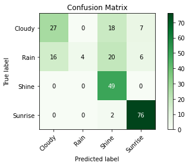

```python
# The performance metrics are calculated according to the parameteres below  (PARAMETER EXTRA TRIAL 4) batchsize = 44, lr=5e-2

"""
Plot for the listed parameters below:
max_epoch = 14
train_batch = 44
test_batch = 44
learning_rate = 0.1
momentum = 0.5
weight_decay = 5e-04
"""


model_fcn = FCNet()
model_fcn.load_state_dict(torch.load(PATH_FCN_SGD))

# evaluate on test set
# model = model.eval()

predictions = []

with torch.no_grad():
#   iterate over test batches
    for data in test_loader:
        images, labels = data
        images = images.permute(0, 3, 1, 2)
        #images, labels = images.cuda(), labels.cuda()
        outputs = model_fcn(images.float())
        _, predicted2 = torch.max(outputs.data, 1)
        predictions.extend(predicted2.tolist())

#   get confusion matrix
#   calculate accuracy
#   calculate precision
#   calculate recall
#   calculate F1 score
labelAndNames = {0: "Cloudy", 1: "Rain", 2: "Shine", 3: "Sunrise"}
cm = confusion_matrix(y_test,predictions)
# plot confusion matrix
plot_cm(cm, labelAndNames.values())
pscore = precision_score(y_test, predictions, average="macro")
rscore = recall_score(y_test, predictions, average="macro")
f1 = f1_score(y_test, predictions, average="macro")
print("Macro Precision:", pscore, "Macro Recall:", rscore,"Macro F1:" ,f1)
print("Accuracy", accuracy_score(y_test,predictions))
acc_per_class = cm.diagonal()/cm.sum(1)
print("Accuracies for each class:")
for i, acc in enumerate(acc_per_class):
    print(f'\tAccuracy for {labelAndNames[i]}'.ljust(30, ' '), acc)
```

```python
# The model trained according to the parameteres below (PARAMETER EXTRA TRIAL 5) BATCHSIZE= 44, LR=5e-3

max_epoch = 14
train_batch = 44
test_batch = 44
learning_rate = 5e-3
momentum = 0.5
weight_decay = 5e-04

model_FCN = FCNet()
criterion = nn.CrossEntropyLoss()
min_vald_loss = np.inf
optimizer = torch.optim.SGD(model_FCN.parameters(), lr=learning_rate, weight_decay=5e-04)

PATH_FCN_SGD = "/content/drive/MyDrive/CS464_HW3/best_fcn_sgd.pth"
min_vald_loss = np.inf
history = {'train_accuracy': [], 'vald_accuracy':[], 'train_loss': [], 'vald_loss': []}

for epoch in range(max_epoch):
    train_loss = 0.0
    train_correct = 0
    for i, data in enumerate(train_loader, 0):
        inputs, labels = data
        optimizer.zero_grad()
        input = inputs.permute(0, 3, 1, 2)
        outputs = model_FCN(input.float())
        preds = torch.argmax(outputs, dim=1)
        train_correct += torch.sum(preds==labels)
        loss = criterion(outputs, labels)
        loss.backward()
        optimizer.step()
        train_loss += loss.item()

    with torch.no_grad():
        vald_loss = 0.0
        vald_correct = 0
        for data in validation_loader:
            images, labels = data
            images = images.permute(0, 3, 1, 2)
            outputs = model_FCN(images.float())
            preds = torch.argmax(outputs, dim=1)
            vald_correct += torch.sum(preds==labels)
            loss = criterion(outputs, labels)
            vald_loss += loss.item()

    print(f'Epoch {epoch+1}:\t\t train_loss: {(train_loss / len(train_loader)):.2f}\t\t train_accuracy: {(train_correct / (len(train_loader) * train_batch)):.2f}\t\t validation_loss: {(vald_loss / len(validation_loader)):.2f}\t\t validation_accuracy: {(vald_correct / (len(validation_loader) * test_batch)):.2f}')
    if (vald_loss / len(validation_loader)) < min_vald_loss:
        print(f'Saving new best FCN SGD with vald_loss: {(vald_loss / len(validation_loader)):.2f}')
        min_vald_loss = (vald_loss / len(validation_loader))
        torch.save(model_FCN.state_dict(), PATH_FCN_SGD)

    history['train_loss'].append(train_loss / len(train_loader))
    history['vald_loss'].append(vald_loss / len(validation_loader))
    history['train_accuracy'].append(train_correct / (len(train_loader) * train_batch))
    history['vald_accuracy'].append(vald_correct / (len(validation_loader) * test_batch))

print(f'Best validation loss: {min_vald_loss}')
```

```
Epoch 1:		 train_loss: 1.33		 train_accuracy: 0.65		 validation_loss: 1.28		 validation_accuracy: 0.68
Saving new best FCN SGD with vald_loss: 1.28
Epoch 2:		 train_loss: 1.21		 train_accuracy: 0.83		 validation_loss: 1.16		 validation_accuracy: 0.70
Saving new best FCN SGD with vald_loss: 1.16
Epoch 3:		 train_loss: 1.08		 train_accuracy: 0.86		 validation_loss: 1.05		 validation_accuracy: 0.70
Saving new best FCN SGD with vald_loss: 1.05
Epoch 4:		 train_loss: 0.97		 train_accuracy: 0.90		 validation_loss: 0.95		 validation_accuracy: 0.73
Saving new best FCN SGD with vald_loss: 0.95
Epoch 5:		 train_loss: 0.88		 train_accuracy: 0.93		 validation_loss: 0.88		 validation_accuracy: 0.80
Saving new best FCN SGD with vald_loss: 0.88
Epoch 6:		 train_loss: 0.82		 train_accuracy: 0.98		 validation_loss: 0.83		 validation_accuracy: 0.81
Saving new best FCN SGD with vald_loss: 0.83
Epoch 7:		 train_loss: 0.76		 train_accuracy: 1.00		 validation_loss: 0.78		 validation_accuracy: 0.84
Saving new best FCN SGD with vald_loss: 0.78
Epoch 8:		 train_loss: 0.72		 train_accuracy: 1.03		 validation_loss: 0.74		 validation_accuracy: 0.88
Saving new best FCN SGD with vald_loss: 0.74
Epoch 9:		 train_loss: 0.69		 train_accuracy: 1.06		 validation_loss: 0.71		 validation_accuracy: 0.92
Saving new best FCN SGD with vald_loss: 0.71
Epoch 10:		 train_loss: 0.66		 train_accuracy: 1.08		 validation_loss: 0.68		 validation_accuracy: 0.94
Saving new best FCN SGD with vald_loss: 0.68
Epoch 11:		 train_loss: 0.63		 train_accuracy: 1.09		 validation_loss: 0.65		 validation_accuracy: 0.94
Saving new best FCN SGD with vald_loss: 0.65
Epoch 12:		 train_loss: 0.61		 train_accuracy: 1.10		 validation_loss: 0.64		 validation_accuracy: 0.95
Saving new best FCN SGD with vald_loss: 0.64
Epoch 13:		 train_loss: 0.59		 train_accuracy: 1.10		 validation_loss: 0.62		 validation_accuracy: 0.98
Saving new best FCN SGD with vald_loss: 0.62
Epoch 14:		 train_loss: 0.57		 train_accuracy: 1.12		 validation_loss: 0.60		 validation_accuracy: 0.95
Saving new best FCN SGD with vald_loss: 0.60
Best validation loss: 0.6044226288795471
```

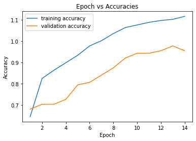

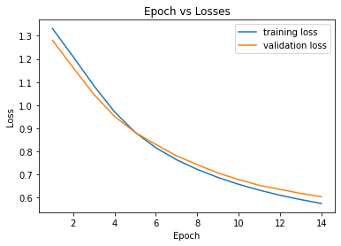

```python
# The graphs plotted according to the parameteres below  (PARAMETER EXTRA TRIAL 5) batchsize = 44, lr=5e-3
"""
Plot for the listed parameters below:
max_epoch = 14
train_batch = 44
test_batch = 44
learning_rate = 5e-3
momentum = 0.5
weight_decay = 5e-04
"""

# plot accuracies vs epoch -- PLOT 1
plt.plot([i+1 for i in range(max_epoch)], history['train_accuracy'], label='training accuracy')
plt.plot([i+1 for i in range(max_epoch)], history['vald_accuracy'], label='validation accuracy')
plt.xlabel('Epoch')
plt.ylabel('Accuracy')
plt.title('Epoch vs Accuracies')
plt.legend(loc='upper left')
plt.show()


# plot losses vs epoch -- PLOT 2
plt.plot([i+1 for i in range(max_epoch)], history['train_loss'], label='training loss')
plt.plot([i+1 for i in range(max_epoch)], history['vald_loss'], label='validation loss')
plt.xlabel('Epoch')
plt.ylabel('Loss')
plt.title('Epoch vs Losses')
plt.legend(loc='upper right')
plt.show()
```

```
Macro Precision: 0.7763806100981767 Macro Recall: 0.7184592064250449 Macro F1: 0.7059099683840324
Accuracy 0.7555555555555555
Accuracies for each class:
	Accuracy for Cloudy           0.6346153846153846
	Accuracy for Rain             0.32608695652173914
	Accuracy for Shine            0.9387755102040817
	Accuracy for Sunrise          0.9743589743589743
```

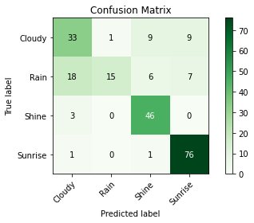

```python
# The performance metrics are calculated according to the parameteres below  (PARAMETER EXTRA TRIAL 5) batchsize = 44, lr=5e-3

"""
Plot for the listed parameters below:
max_epoch = 14
train_batch = 44
test_batch = 44
learning_rate = 5e-3
momentum = 0.5
weight_decay = 5e-04
"""


model_fcn = FCNet()
model_fcn.load_state_dict(torch.load(PATH_FCN_SGD))

# evaluate on test set
# model = model.eval()

predictions = []

with torch.no_grad():
#   iterate over test batches
    for data in test_loader:
        images, labels = data
        images = images.permute(0, 3, 1, 2)
        #images, labels = images.cuda(), labels.cuda()
        outputs = model_fcn(images.float())
        _, predicted2 = torch.max(outputs.data, 1)
        predictions.extend(predicted2.tolist())

#   get confusion matrix
#   calculate accuracy
#   calculate precision
#   calculate recall
#   calculate F1 score
labelAndNames = {0: "Cloudy", 1: "Rain", 2: "Shine", 3: "Sunrise"}
cm = confusion_matrix(y_test,predictions)
# plot confusion matrix
plot_cm(cm, labelAndNames.values())
pscore = precision_score(y_test, predictions, average="macro")
rscore = recall_score(y_test, predictions, average="macro")
f1 = f1_score(y_test, predictions, average="macro")
print("Macro Precision:", pscore, "Macro Recall:", rscore,"Macro F1:" ,f1)
print("Accuracy", accuracy_score(y_test,predictions))
acc_per_class = cm.diagonal()/cm.sum(1)
print("Accuracies for each class:")
for i, acc in enumerate(acc_per_class):
    print(f'\tAccuracy for {labelAndNames[i]}'.ljust(30, ' '), acc)
```

## Training and evaluation of CNN [22 points]

Similar to the FCN model, you will now train the CNN model that you defined before. Again you are free to try out different hyperparameters. This model also will classify weather images with the four classes provided by the dataset. As the optimizer, again, use the SGD implementation provided by PyTorch. You can implement the training loop in the following cell.

Similar to the training procedure, you need to save the best model you obtain during training. Select an appropriate criterion (metric) to save the best model. If you wish, you can add a markdown cell to explain your reasoning.

### Training [12 points]

```python
# CNN
max_epoch = 14
train_batch = 64
test_batch = 64
learning_rate = 0.1
momentum = 0.5
weight_decay = 5e-04

model_CNN = ConvNet()
criterion = nn.CrossEntropyLoss()
optimizer = torch.optim.SGD(model_CNN.parameters(), lr=learning_rate, weight_decay=5e-04) # you can play with weight_decay as well but do not add additional parameters

PATH_CNN_SGD = "/content/drive/MyDrive/CS464_HW3/best_cnn_sgd.pth"
min_vald_loss = np.inf
history = {'train_accuracy': [], 'vald_accuracy':[], 'train_loss': [], 'vald_loss': []}

for epoch in range(max_epoch):
    train_loss = 0.0
    train_correct = 0
    for i, data in enumerate(train_loader, 0):
        inputs, labels = data
        optimizer.zero_grad()
        input = inputs.permute(0, 3, 1, 2)
        outputs = model_CNN(input.float())
        preds = torch.argmax(outputs, dim=1)
        train_correct += torch.sum(preds==labels)
        loss = criterion(outputs, labels)
        loss.backward()
        optimizer.step()
        train_loss += loss.item()

    with torch.no_grad():
        vald_loss = 0.0
        vald_correct = 0
        for data in validation_loader:
            images, labels = data
            images = images.permute(0, 3, 1, 2)
            outputs = model_CNN(images.float())
            preds = torch.argmax(outputs, dim=1)
            vald_correct += torch.sum(preds==labels)
            loss = criterion(outputs, labels)
            vald_loss += loss.item()

    print(f'Epoch {epoch+1}:\t\t train_loss: {(train_loss / len(train_loader)):.2f}\t\t train_accuracy: {(train_correct / (len(train_loader) * train_batch)):.2f}\t\t validation_loss: {(vald_loss / len(validation_loader)):.2f}\t\t validation_accuracy: {(vald_correct / (len(validation_loader) * test_batch)):.2f}')
    if (vald_loss / len(validation_loader)) < min_vald_loss:
        print(f'Saving new best CNN SGD with vald_loss: {(vald_loss / len(validation_loader)):.2f}')
        min_vald_loss = (vald_loss / len(validation_loader))
        torch.save(model_CNN.state_dict(), PATH_CNN_SGD)

    history['train_loss'].append(train_loss / len(train_loader))
    history['vald_loss'].append(vald_loss / len(validation_loader))
    history['train_accuracy'].append(train_correct / (len(train_loader) * train_batch))
    history['vald_accuracy'].append(vald_correct / (len(validation_loader) * test_batch))

print(f'Best validation loss: {min_vald_loss}')
```

```
Epoch 1:		 train_loss: 1.36		 train_accuracy: 0.31		 validation_loss: 1.25		 validation_accuracy: 0.48
Saving new best CNN SGD with vald_loss: 1.25
Epoch 2:		 train_loss: 1.27		 train_accuracy: 0.43		 validation_loss: 1.43		 validation_accuracy: 0.27
Epoch 3:		 train_loss: 1.28		 train_accuracy: 0.41		 validation_loss: 1.16		 validation_accuracy: 0.48
Saving new best CNN SGD with vald_loss: 1.16
Epoch 4:		 train_loss: 1.14		 train_accuracy: 0.55		 validation_loss: 1.14		 validation_accuracy: 0.52
Saving new best CNN SGD with vald_loss: 1.14
Epoch 5:		 train_loss: 1.15		 train_accuracy: 0.55		 validation_loss: 1.35		 validation_accuracy: 0.30
Epoch 6:		 train_loss: 1.14		 train_accuracy: 0.55		 validation_loss: 1.20		 validation_accuracy: 0.46
Epoch 7:		 train_loss: 1.09		 train_accuracy: 0.60		 validation_loss: 1.17		 validation_accuracy: 0.48
Epoch 8:		 train_loss: 1.04		 train_accuracy: 0.65		 validation_loss: 1.07		 validation_accuracy: 0.60
Saving new best CNN SGD with vald_loss: 1.07
Epoch 9:		 train_loss: 0.99		 train_accuracy: 0.71		 validation_loss: 0.91		 validation_accuracy: 0.73
Saving new best CNN SGD with vald_loss: 0.91
Epoch 10:		 train_loss: 1.00		 train_accuracy: 0.70		 validation_loss: 1.21		 validation_accuracy: 0.48
Epoch 11:		 train_loss: 0.97		 train_accuracy: 0.72		 validation_loss: 1.08		 validation_accuracy: 0.57
Epoch 12:		 train_loss: 0.94		 train_accuracy: 0.76		 validation_loss: 0.92		 validation_accuracy: 0.73
Epoch 13:		 train_loss: 0.91		 train_accuracy: 0.78		 validation_loss: 0.86		 validation_accuracy: 0.79
Saving new best CNN SGD with vald_loss: 0.86
Epoch 14:		 train_loss: 0.90		 train_accuracy: 0.79		 validation_loss: 0.86		 validation_accuracy: 0.77
Best validation loss: 0.855176717042923
```

### Learning Process Analysis [3 points]

Repeating the same procedure you applied for the FCN model; you will provide two plots about how your training proceeds over epochs. Again, provide two plots: one summarizes the loss values, and the other summarizes the accuracy values. Note that each plot needs to include two curves, one for the validation set and the other for the training set.

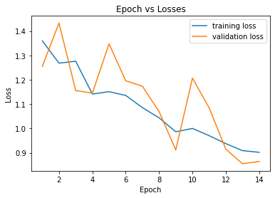

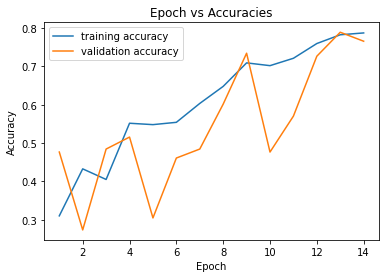

```python
# plot losses vs epoch
plt.plot([i+1 for i in range(max_epoch)], history['train_loss'], label='training loss')
plt.plot([i+1 for i in range(max_epoch)], history['vald_loss'], label='validation loss')
plt.xlabel('Epoch')
plt.ylabel('Loss')
plt.title('Epoch vs Losses')
plt.legend(loc='upper right')
plt.show()

# plot accuracies vs epoch
plt.plot([i+1 for i in range(max_epoch)], history['train_accuracy'], label='training accuracy')
plt.plot([i+1 for i in range(max_epoch)], history['vald_accuracy'], label='validation accuracy')
plt.xlabel('Epoch')
plt.ylabel('Accuracy')
plt.title('Epoch vs Accuracies')
plt.legend(loc='upper left')
plt.show()
```

### Test [4 points]

Concluding your analysis, report the confusion matrix for the best model you obtained during your CNN model training. Then using this confusion matrix, report accuracy, recall, precision, and $F_1$ score for your best model. Use macro averaging in all of your metrics.

```
Macro Precision: 0.7928952991452992 Macro Recall: 0.7859062521329603 Macro F1: 0.7812231496087162
Accuracy 0.8133333333333334
Accuracies for each class:
	Accuracy for Cloudy           0.5961538461538461
	Accuracy for Rain             0.6086956521739131
	Accuracy for Shine            0.9387755102040817
	Accuracy for Sunrise          1.0
```

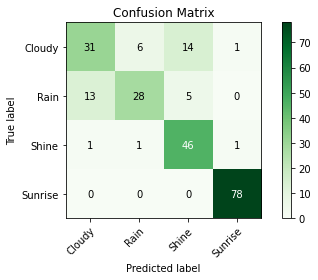

```python
model_cnn = ConvNet()
model_cnn.load_state_dict(torch.load(PATH_CNN_SGD))

# evaluate on test set
# model = model.eval()

predictions = []

with torch.no_grad():
#   iterate over test batches
    for data in test_loader:
        images, labels = data
        images = images.permute(0, 3, 1, 2)
        #images, labels = images.cuda(), labels.cuda()
        outputs = model_cnn(images.float())
        _, predicted2 = torch.max(outputs.data, 1)
        predictions.extend(predicted2.tolist())

#   get confusion matrix
#   calculate accuracy
#   calculate precision
#   calculate recall
#   calculate F1 score
labelAndNames = {0: "Cloudy", 1: "Rain", 2: "Shine", 3: "Sunrise"}
cm = confusion_matrix(y_test,predictions)
# plot confusion matrix
plot_cm(cm, labelAndNames.values())
pscore = precision_score(y_test, predictions, average="macro")
rscore = recall_score(y_test, predictions, average="macro")
f1 = f1_score(y_test, predictions, average="macro")
print("Macro Precision:", pscore, "Macro Recall:", rscore,"Macro F1:" ,f1)
print("Accuracy", accuracy_score(y_test,predictions))
acc_per_class = cm.diagonal()/cm.sum(1)
print("Accuracies for each class:")
for i, acc in enumerate(acc_per_class):
    print(f'\tAccuracy for {labelAndNames[i]}'.ljust(30, ' '), acc)
```

```python
# CNN  (PARAMETER EXTRA TRIAL 1 FOR CNN)(BATCHSIZE:64, LR:5e-2)
max_epoch = 14
train_batch = 64
test_batch = 64
learning_rate = 5e-2
momentum = 0.5
weight_decay = 5e-04

model_CNN = ConvNet()
criterion = nn.CrossEntropyLoss()
optimizer = torch.optim.SGD(model_CNN.parameters(), lr=learning_rate, weight_decay=5e-04) # you can play with weight_decay as well but do not add additional parameters

PATH_CNN_SGD = "/content/drive/MyDrive/CS464_HW3/best_cnn_sgd.pth"
min_vald_loss = np.inf
history = {'train_accuracy': [], 'vald_accuracy':[], 'train_loss': [], 'vald_loss': []}

for epoch in range(max_epoch):
    train_loss = 0.0
    train_correct = 0
    for i, data in enumerate(train_loader, 0):
        inputs, labels = data
        optimizer.zero_grad()
        input = inputs.permute(0, 3, 1, 2)
        outputs = model_CNN(input.float())
        preds = torch.argmax(outputs, dim=1)
        train_correct += torch.sum(preds==labels)
        loss = criterion(outputs, labels)
        loss.backward()
        optimizer.step()
        train_loss += loss.item()

    with torch.no_grad():
        vald_loss = 0.0
        vald_correct = 0
        for data in validation_loader:
            images, labels = data
            images = images.permute(0, 3, 1, 2)
            outputs = model_CNN(images.float())
            preds = torch.argmax(outputs, dim=1)
            vald_correct += torch.sum(preds==labels)
            loss = criterion(outputs, labels)
            vald_loss += loss.item()

    print(f'Epoch {epoch+1}:\t\t train_loss: {(train_loss / len(train_loader)):.2f}\t\t train_accuracy: {(train_correct / (len(train_loader) * train_batch)):.2f}\t\t validation_loss: {(vald_loss / len(validation_loader)):.2f}\t\t validation_accuracy: {(vald_correct / (len(validation_loader) * test_batch)):.2f}')
    if (vald_loss / len(validation_loader)) < min_vald_loss:
        print(f'Saving new best CNN SGD with vald_loss: {(vald_loss / len(validation_loader)):.2f}')
        min_vald_loss = (vald_loss / len(validation_loader))
        torch.save(model_CNN.state_dict(), PATH_CNN_SGD)

    history['train_loss'].append(train_loss / len(train_loader))
    history['vald_loss'].append(vald_loss / len(validation_loader))
    history['train_accuracy'].append(train_correct / (len(train_loader) * train_batch))
    history['vald_accuracy'].append(vald_correct / (len(validation_loader) * test_batch))

print(f'Best validation loss: {min_vald_loss}')
```

```
Epoch 1:		 train_loss: 1.36		 train_accuracy: 0.30		 validation_loss: 1.27		 validation_accuracy: 0.45
Saving new best CNN SGD with vald_loss: 1.27
Epoch 2:		 train_loss: 1.28		 train_accuracy: 0.41		 validation_loss: 1.23		 validation_accuracy: 0.43
Saving new best CNN SGD with vald_loss: 1.23
Epoch 3:		 train_loss: 1.16		 train_accuracy: 0.55		 validation_loss: 1.37		 validation_accuracy: 0.30
Epoch 4:		 train_loss: 1.16		 train_accuracy: 0.53		 validation_loss: 1.16		 validation_accuracy: 0.47
Saving new best CNN SGD with vald_loss: 1.16
Epoch 5:		 train_loss: 1.07		 train_accuracy: 0.63		 validation_loss: 0.99		 validation_accuracy: 0.69
Saving new best CNN SGD with vald_loss: 0.99
Epoch 6:		 train_loss: 0.99		 train_accuracy: 0.72		 validation_loss: 0.93		 validation_accuracy: 0.73
Saving new best CNN SGD with vald_loss: 0.93
Epoch 7:		 train_loss: 0.98		 train_accuracy: 0.73		 validation_loss: 1.02		 validation_accuracy: 0.63
Epoch 8:		 train_loss: 1.03		 train_accuracy: 0.66		 validation_loss: 0.98		 validation_accuracy: 0.69
Epoch 9:		 train_loss: 0.97		 train_accuracy: 0.74		 validation_loss: 1.06		 validation_accuracy: 0.60
Epoch 10:		 train_loss: 0.93		 train_accuracy: 0.77		 validation_loss: 0.90		 validation_accuracy: 0.76
Saving new best CNN SGD with vald_loss: 0.90
Epoch 11:		 train_loss: 0.94		 train_accuracy: 0.75		 validation_loss: 0.96		 validation_accuracy: 0.69
Epoch 12:		 train_loss: 0.94		 train_accuracy: 0.75		 validation_loss: 1.02		 validation_accuracy: 0.61
Epoch 13:		 train_loss: 0.93		 train_accuracy: 0.77		 validation_loss: 0.99		 validation_accuracy: 0.65
Epoch 14:		 train_loss: 0.91		 train_accuracy: 0.79		 validation_loss: 0.99		 validation_accuracy: 0.66
Best validation loss: 0.9031980633735657
```

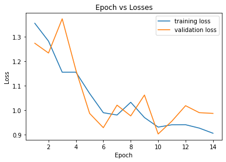

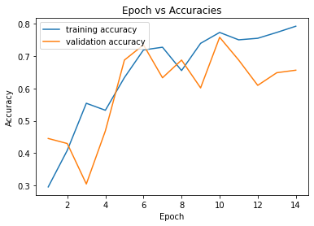

```python
# CNN  (PARAMETER EXTRA TRIAL 1 FOR CNN)(BATCHSIZE:64, LR:5e-2)
# plot losses vs epoch
plt.plot([i+1 for i in range(max_epoch)], history['train_loss'], label='training loss')
plt.plot([i+1 for i in range(max_epoch)], history['vald_loss'], label='validation loss')
plt.xlabel('Epoch')
plt.ylabel('Loss')
plt.title('Epoch vs Losses')
plt.legend(loc='upper right')
plt.show()

# plot accuracies vs epoch
plt.plot([i+1 for i in range(max_epoch)], history['train_accuracy'], label='training accuracy')
plt.plot([i+1 for i in range(max_epoch)], history['vald_accuracy'], label='validation accuracy')
plt.xlabel('Epoch')
plt.ylabel('Accuracy')
plt.title('Epoch vs Accuracies')
plt.legend(loc='upper left')
plt.show()
```

```
Macro Precision: 0.8208189885556185 Macro Recall: 0.7837306327213159 Macro F1: 0.7865672030943216
Accuracy 0.8133333333333334
Accuracies for each class:
	Accuracy for Cloudy           0.6730769230769231
	Accuracy for Rain             0.5434782608695652
	Accuracy for Shine            0.9183673469387755
	Accuracy for Sunrise          1.0
```

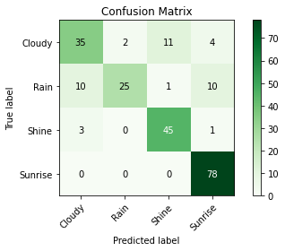

```python
# CNN  (PARAMETER EXTRA TRIAL 1 FOR CNN)(BATCHSIZE:64, LR:5e-2)
model_cnn = ConvNet()
model_cnn.load_state_dict(torch.load(PATH_CNN_SGD))

# evaluate on test set
# model = model.eval()

predictions = []

with torch.no_grad():
#   iterate over test batches
    for data in test_loader:
        images, labels = data
        images = images.permute(0, 3, 1, 2)
        #images, labels = images.cuda(), labels.cuda()
        outputs = model_cnn(images.float())
        _, predicted2 = torch.max(outputs.data, 1)
        predictions.extend(predicted2.tolist())

#   get confusion matrix
#   calculate accuracy
#   calculate precision
#   calculate recall
#   calculate F1 score
labelAndNames = {0: "Cloudy", 1: "Rain", 2: "Shine", 3: "Sunrise"}
cm = confusion_matrix(y_test,predictions)
# plot confusion matrix
plot_cm(cm, labelAndNames.values())
pscore = precision_score(y_test, predictions, average="macro")
rscore = recall_score(y_test, predictions, average="macro")
f1 = f1_score(y_test, predictions, average="macro")
print("Macro Precision:", pscore, "Macro Recall:", rscore,"Macro F1:" ,f1)
print("Accuracy", accuracy_score(y_test,predictions))
acc_per_class = cm.diagonal()/cm.sum(1)
print("Accuracies for each class:")
for i, acc in enumerate(acc_per_class):
    print(f'\tAccuracy for {labelAndNames[i]}'.ljust(30, ' '), acc)
```

```python
# CNN  (PARAMETER EXTRA TRIAL 2 FOR CNN)(BATCHSIZE:64, LR:5e-3)
max_epoch = 14
train_batch = 64
test_batch = 64
learning_rate = 5e-3
momentum = 0.5
weight_decay = 5e-04

model_CNN = ConvNet()
criterion = nn.CrossEntropyLoss()
optimizer = torch.optim.SGD(model_CNN.parameters(), lr=learning_rate, weight_decay=5e-04) # you can play with weight_decay as well but do not add additional parameters

PATH_CNN_SGD = "/content/drive/MyDrive/CS464_HW3/best_cnn_sgd.pth"
min_vald_loss = np.inf
history = {'train_accuracy': [], 'vald_accuracy':[], 'train_loss': [], 'vald_loss': []}

for epoch in range(max_epoch):
    train_loss = 0.0
    train_correct = 0
    for i, data in enumerate(train_loader, 0):
        inputs, labels = data
        optimizer.zero_grad()
        input = inputs.permute(0, 3, 1, 2)
        outputs = model_CNN(input.float())
        preds = torch.argmax(outputs, dim=1)
        train_correct += torch.sum(preds==labels)
        loss = criterion(outputs, labels)
        loss.backward()
        optimizer.step()
        train_loss += loss.item()

    with torch.no_grad():
        vald_loss = 0.0
        vald_correct = 0
        for data in validation_loader:
            images, labels = data
            images = images.permute(0, 3, 1, 2)
            outputs = model_CNN(images.float())
            preds = torch.argmax(outputs, dim=1)
            vald_correct += torch.sum(preds==labels)
            loss = criterion(outputs, labels)
            vald_loss += loss.item()

    print(f'Epoch {epoch+1}:\t\t train_loss: {(train_loss / len(train_loader)):.2f}\t\t train_accuracy: {(train_correct / (len(train_loader) * train_batch)):.2f}\t\t validation_loss: {(vald_loss / len(validation_loader)):.2f}\t\t validation_accuracy: {(vald_correct / (len(validation_loader) * test_batch)):.2f}')
    if (vald_loss / len(validation_loader)) < min_vald_loss:
        print(f'Saving new best CNN SGD with vald_loss: {(vald_loss / len(validation_loader)):.2f}')
        min_vald_loss = (vald_loss / len(validation_loader))
        torch.save(model_CNN.state_dict(), PATH_CNN_SGD)

    history['train_loss'].append(train_loss / len(train_loader))
    history['vald_loss'].append(vald_loss / len(validation_loader))
    history['train_accuracy'].append(train_correct / (len(train_loader) * train_batch))
    history['vald_accuracy'].append(vald_correct / (len(validation_loader) * test_batch))

print(f'Best validation loss: {min_vald_loss}')
```

```
Epoch 1:		 train_loss: 1.38		 train_accuracy: 0.25		 validation_loss: 1.38		 validation_accuracy: 0.27
Saving new best CNN SGD with vald_loss: 1.38
Epoch 2:		 train_loss: 1.37		 train_accuracy: 0.30		 validation_loss: 1.38		 validation_accuracy: 0.27
Saving new best CNN SGD with vald_loss: 1.38
Epoch 3:		 train_loss: 1.36		 train_accuracy: 0.30		 validation_loss: 1.38		 validation_accuracy: 0.27
Saving new best CNN SGD with vald_loss: 1.38
Epoch 4:		 train_loss: 1.36		 train_accuracy: 0.30		 validation_loss: 1.38		 validation_accuracy: 0.27
Saving new best CNN SGD with vald_loss: 1.38
Epoch 5:		 train_loss: 1.35		 train_accuracy: 0.31		 validation_loss: 1.37		 validation_accuracy: 0.27
Saving new best CNN SGD with vald_loss: 1.37
Epoch 6:		 train_loss: 1.34		 train_accuracy: 0.32		 validation_loss: 1.36		 validation_accuracy: 0.27
Saving new best CNN SGD with vald_loss: 1.36
Epoch 7:		 train_loss: 1.33		 train_accuracy: 0.33		 validation_loss: 1.34		 validation_accuracy: 0.31
Saving new best CNN SGD with vald_loss: 1.34
Epoch 8:		 train_loss: 1.32		 train_accuracy: 0.38		 validation_loss: 1.32		 validation_accuracy: 0.34
Saving new best CNN SGD with vald_loss: 1.32
Epoch 9:		 train_loss: 1.29		 train_accuracy: 0.44		 validation_loss: 1.29		 validation_accuracy: 0.42
Saving new best CNN SGD with vald_loss: 1.29
Epoch 10:		 train_loss: 1.27		 train_accuracy: 0.47		 validation_loss: 1.26		 validation_accuracy: 0.45
Saving new best CNN SGD with vald_loss: 1.26
Epoch 11:		 train_loss: 1.24		 train_accuracy: 0.49		 validation_loss: 1.24		 validation_accuracy: 0.48
Saving new best CNN SGD with vald_loss: 1.24
Epoch 12:		 train_loss: 1.21		 train_accuracy: 0.53		 validation_loss: 1.21		 validation_accuracy: 0.49
Saving new best CNN SGD with vald_loss: 1.21
Epoch 13:		 train_loss: 1.19		 train_accuracy: 0.57		 validation_loss: 1.20		 validation_accuracy: 0.52
Saving new best CNN SGD with vald_loss: 1.20
Epoch 14:		 train_loss: 1.17		 train_accuracy: 0.59		 validation_loss: 1.18		 validation_accuracy: 0.55
Saving new best CNN SGD with vald_loss: 1.18
Best validation loss: 1.182533621788025
```

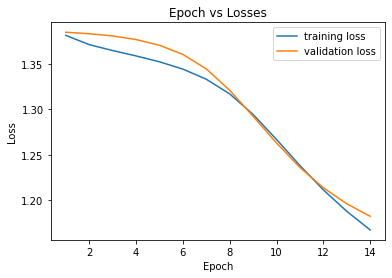

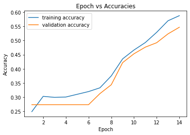

```python
# CNN  (PARAMETER EXTRA TRIAL 2 FOR CNN)(BATCHSIZE:64, LR:5e-3)
# plot losses vs epoch
plt.plot([i+1 for i in range(max_epoch)], history['train_loss'], label='training loss')
plt.plot([i+1 for i in range(max_epoch)], history['vald_loss'], label='validation loss')
plt.xlabel('Epoch')
plt.ylabel('Loss')
plt.title('Epoch vs Losses')
plt.legend(loc='upper right')
plt.show()

# plot accuracies vs epoch
plt.plot([i+1 for i in range(max_epoch)], history['train_accuracy'], label='training accuracy')
plt.plot([i+1 for i in range(max_epoch)], history['vald_accuracy'], label='validation accuracy')
plt.xlabel('Epoch')
plt.ylabel('Accuracy')
plt.title('Epoch vs Accuracies')
plt.legend(loc='upper left')
plt.show()
```

```
Macro Precision: 0.45091091992352494 Macro Recall: 0.551380167451596 Macro F1: 0.493501755540926
Accuracy 0.6133333333333333
Accuracies for each class:
	Accuracy for Cloudy           0.5576923076923077
	Accuracy for Rain             0.0
	Accuracy for Shine            0.673469387755102
	Accuracy for Sunrise          0.9743589743589743
```

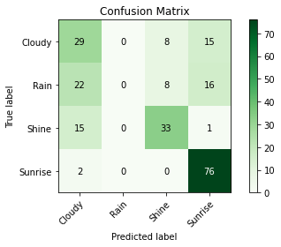

```python
# CNN  (PARAMETER EXTRA TRIAL 2 FOR CNN)(BATCHSIZE:64, LR:5e-3)
model_cnn = ConvNet()
model_cnn.load_state_dict(torch.load(PATH_CNN_SGD))

# evaluate on test set
# model = model.eval()

predictions = []

with torch.no_grad():
#   iterate over test batches
    for data in test_loader:
        images, labels = data
        images = images.permute(0, 3, 1, 2)
        #images, labels = images.cuda(), labels.cuda()
        outputs = model_cnn(images.float())
        _, predicted2 = torch.max(outputs.data, 1)
        predictions.extend(predicted2.tolist())

#   get confusion matrix
#   calculate accuracy
#   calculate precision
#   calculate recall
#   calculate F1 score
labelAndNames = {0: "Cloudy", 1: "Rain", 2: "Shine", 3: "Sunrise"}
cm = confusion_matrix(y_test,predictions)
# plot confusion matrix
plot_cm(cm, labelAndNames.values())
pscore = precision_score(y_test, predictions, average="macro")
rscore = recall_score(y_test, predictions, average="macro")
f1 = f1_score(y_test, predictions, average="macro")
print("Macro Precision:", pscore, "Macro Recall:", rscore,"Macro F1:" ,f1)
print("Accuracy", accuracy_score(y_test,predictions))
acc_per_class = cm.diagonal()/cm.sum(1)
print("Accuracies for each class:")
for i, acc in enumerate(acc_per_class):
    print(f'\tAccuracy for {labelAndNames[i]}'.ljust(30, ' '), acc)
```

```python
# CNN  (PARAMETER EXTRA TRIAL 3 FOR CNN)(BATCHSIZE:44, LR:0.1)
max_epoch = 14
train_batch = 44
test_batch = 44
learning_rate = 0.1
momentum = 0.5
weight_decay = 5e-04

model_CNN = ConvNet()
criterion = nn.CrossEntropyLoss()
optimizer = torch.optim.SGD(model_CNN.parameters(), lr=learning_rate, weight_decay=5e-04) # you can play with weight_decay as well but do not add additional parameters

PATH_CNN_SGD = "/content/drive/MyDrive/CS464_HW3/best_cnn_sgd.pth"
min_vald_loss = np.inf
history = {'train_accuracy': [], 'vald_accuracy':[], 'train_loss': [], 'vald_loss': []}

for epoch in range(max_epoch):
    train_loss = 0.0
    train_correct = 0
    for i, data in enumerate(train_loader, 0):
        inputs, labels = data
        optimizer.zero_grad()
        input = inputs.permute(0, 3, 1, 2)
        outputs = model_CNN(input.float())
        preds = torch.argmax(outputs, dim=1)
        train_correct += torch.sum(preds==labels)
        loss = criterion(outputs, labels)
        loss.backward()
        optimizer.step()
        train_loss += loss.item()

    with torch.no_grad():
        vald_loss = 0.0
        vald_correct = 0
        for data in validation_loader:
            images, labels = data
            images = images.permute(0, 3, 1, 2)
            outputs = model_CNN(images.float())
            preds = torch.argmax(outputs, dim=1)
            vald_correct += torch.sum(preds==labels)
            loss = criterion(outputs, labels)
            vald_loss += loss.item()

    print(f'Epoch {epoch+1}:\t\t train_loss: {(train_loss / len(train_loader)):.2f}\t\t train_accuracy: {(train_correct / (len(train_loader) * train_batch)):.2f}\t\t validation_loss: {(vald_loss / len(validation_loader)):.2f}\t\t validation_accuracy: {(vald_correct / (len(validation_loader) * test_batch)):.2f}')
    if (vald_loss / len(validation_loader)) < min_vald_loss:
        print(f'Saving new best CNN SGD with vald_loss: {(vald_loss / len(validation_loader)):.2f}')
        min_vald_loss = (vald_loss / len(validation_loader))
        torch.save(model_CNN.state_dict(), PATH_CNN_SGD)

    history['train_loss'].append(train_loss / len(train_loader))
    history['vald_loss'].append(vald_loss / len(validation_loader))
    history['train_accuracy'].append(train_correct / (len(train_loader) * train_batch))
    history['vald_accuracy'].append(vald_correct / (len(validation_loader) * test_batch))

print(f'Best validation loss: {min_vald_loss}')
```

```
Epoch 1:		 train_loss: 1.35		 train_accuracy: 0.47		 validation_loss: 1.28		 validation_accuracy: 0.44
Saving new best CNN SGD with vald_loss: 1.28
Epoch 2:		 train_loss: 1.25		 train_accuracy: 0.65		 validation_loss: 1.23		 validation_accuracy: 0.64
Saving new best CNN SGD with vald_loss: 1.23
Epoch 3:		 train_loss: 1.20		 train_accuracy: 0.72		 validation_loss: 1.27		 validation_accuracy: 0.57
Epoch 4:		 train_loss: 1.13		 train_accuracy: 0.82		 validation_loss: 1.02		 validation_accuracy: 0.98
Saving new best CNN SGD with vald_loss: 1.02
Epoch 5:		 train_loss: 1.05		 train_accuracy: 0.92		 validation_loss: 1.12		 validation_accuracy: 0.78
Epoch 6:		 train_loss: 1.03		 train_accuracy: 0.97		 validation_loss: 0.93		 validation_accuracy: 1.03
Saving new best CNN SGD with vald_loss: 0.93
Epoch 7:		 train_loss: 1.02		 train_accuracy: 0.97		 validation_loss: 1.02		 validation_accuracy: 0.93
Epoch 8:		 train_loss: 0.94		 train_accuracy: 1.10		 validation_loss: 0.89		 validation_accuracy: 1.12
Saving new best CNN SGD with vald_loss: 0.89
Epoch 9:		 train_loss: 0.97		 train_accuracy: 1.04		 validation_loss: 0.89		 validation_accuracy: 1.08
Epoch 10:		 train_loss: 0.91		 train_accuracy: 1.13		 validation_loss: 0.93		 validation_accuracy: 1.05
Epoch 11:		 train_loss: 0.90		 train_accuracy: 1.15		 validation_loss: 1.04		 validation_accuracy: 0.88
Epoch 12:		 train_loss: 0.94		 train_accuracy: 1.10		 validation_loss: 1.07		 validation_accuracy: 0.86
Epoch 13:		 train_loss: 0.92		 train_accuracy: 1.13		 validation_loss: 0.88		 validation_accuracy: 1.11
Saving new best CNN SGD with vald_loss: 0.88
Epoch 14:		 train_loss: 0.93		 train_accuracy: 1.10		 validation_loss: 0.86		 validation_accuracy: 1.14
Saving new best CNN SGD with vald_loss: 0.86
Best validation loss: 0.8572967946529388
```

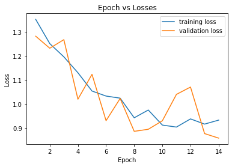

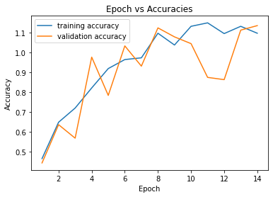

```python
# CNN  (PARAMETER EXTRA TRIAL 3 FOR CNN)(BATCHSIZE:44, LR:0.1)
# plot losses vs epoch
plt.plot([i+1 for i in range(max_epoch)], history['train_loss'], label='training loss')
plt.plot([i+1 for i in range(max_epoch)], history['vald_loss'], label='validation loss')
plt.xlabel('Epoch')
plt.ylabel('Loss')
plt.title('Epoch vs Losses')
plt.legend(loc='upper right')
plt.show()

# plot accuracies vs epoch
plt.plot([i+1 for i in range(max_epoch)], history['train_accuracy'], label='training accuracy')
plt.plot([i+1 for i in range(max_epoch)], history['vald_accuracy'], label='validation accuracy')
plt.xlabel('Epoch')
plt.ylabel('Accuracy')
plt.title('Epoch vs Accuracies')
plt.legend(loc='upper left')
plt.show()
```

```
Macro Precision: 0.8198418003565063 Macro Recall: 0.8057257183809978 Macro F1: 0.8010538380395975
Accuracy 0.8311111111111111
Accuracies for each class:
	Accuracy for Cloudy           0.6346153846153846
	Accuracy for Rain             0.6086956521739131
	Accuracy for Shine            0.9795918367346939
	Accuracy for Sunrise          1.0
```

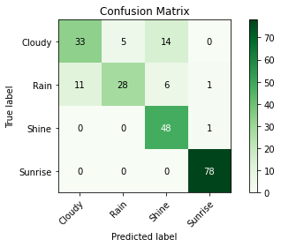

```python
# CNN  (PARAMETER EXTRA TRIAL 3 FOR CNN)(BATCHSIZE:44, LR:0.1)
model_cnn = ConvNet()
model_cnn.load_state_dict(torch.load(PATH_CNN_SGD))

# evaluate on test set
# model = model.eval()

predictions = []

with torch.no_grad():
#   iterate over test batches
    for data in test_loader:
        images, labels = data
        images = images.permute(0, 3, 1, 2)
        #images, labels = images.cuda(), labels.cuda()
        outputs = model_cnn(images.float())
        _, predicted2 = torch.max(outputs.data, 1)
        predictions.extend(predicted2.tolist())

#   get confusion matrix
#   calculate accuracy
#   calculate precision
#   calculate recall
#   calculate F1 score
labelAndNames = {0: "Cloudy", 1: "Rain", 2: "Shine", 3: "Sunrise"}
cm = confusion_matrix(y_test,predictions)
# plot confusion matrix
plot_cm(cm, labelAndNames.values())
pscore = precision_score(y_test, predictions, average="macro")
rscore = recall_score(y_test, predictions, average="macro")
f1 = f1_score(y_test, predictions, average="macro")
print("Macro Precision:", pscore, "Macro Recall:", rscore,"Macro F1:" ,f1)
print("Accuracy", accuracy_score(y_test,predictions))
acc_per_class = cm.diagonal()/cm.sum(1)
print("Accuracies for each class:")
for i, acc in enumerate(acc_per_class):
    print(f'\tAccuracy for {labelAndNames[i]}'.ljust(30, ' '), acc)
```